# main

### Getting Started - Extraction & Transformations

#### Data:

There is both a sqlite db, and a generic sql dump under *db/* so you can use whichever db you prefer.

- student_profiles contains information about a particular student (potential or actual) who has registered interested in a particular course, uniquely identified by a profile_id. For simplicity's sake, profiles are 1:1 with course and school, and the course and school the student expressed interested in is in their profile.
- course_applications contains one record for each course and school a student applied to.
- course_enrollments contains one record for each course and school a student enrolled in.
- student_profiles marked with is_test == true are the unannotated test sample. Their application/enrollment state is excluded to provide a basis for analyzing fit.

```python
%load_ext autoreload
%autoreload 2
%reload_ext autoreload

# Libraries
import sqlite3
import os

import pandas as pd
import numpy as np

from sklearn.model_selection import train_test_split

from sklearn.cluster import KMeans
from sklearn.preprocessing import StandardScaler

from imblearn.over_sampling import SMOTENC, SMOTE

import seaborn as sns
import matplotlib.pyplot as plt
%matplotlib inline

import catboost
import xgboost as xgb

from utilities import evaluate_model, save_pickle_model, load_pickle_model


# Constants
BASE_DIR = os.path.dirname(os.path.dirname(os.path.realpath("__file__")))
DB_DIR = os.path.join(BASE_DIR, "db")
SRC_DIR = os.path.join(BASE_DIR, "src")
DATA_DIR = os.path.join(BASE_DIR, "data")
MODEL_DIR = os.path.join(BASE_DIR, "models")
```

```python
# SQLite connection.
conn = sqlite3.connect(f"{DB_DIR}/funnel.db")

# Check tables in the database
tables = pd.read_sql_query("SELECT * FROM sqlite_master WHERE type='table';", conn)
tables
```

|  | type | name | tbl_name | rootpage | sql |
| --- | --- | --- | --- | --- | --- |
| 0 | table | profile_applications | profile_applications | 294 | CREATE TABLE profile_applications(\n "profile... |
| 1 | table | profile_enrollments | profile_enrollments | 325 | CREATE TABLE profile_enrollments(\n "profile_... |
| 2 | table | student_profiles | student_profiles | 2 | CREATE TABLE student_profiles(\n "profile_id"... |

```python
# Extract student_profiles
student_profiles = pd.read_sql_query("SELECT * FROM student_profiles;", conn)
student_profiles.sample(3)
```

|  | profile_id | school | course_name | country | os_name | experience | lead_initiated | undergrad_grade_points | is_test |
| --- | --- | --- | --- | --- | --- | --- | --- | --- | --- |
| 19156 | 405458331383 | School B | VR | Alfheim | mac os x | Less than 5 Years | false | 98 | false |
| 32398 | 554290356468 | School B | Finance | Rohan |  | 15-20 Years | true | 100 | false |
| 10904 | 234349382193 | School B | Data Science | Spensonia | ios | 10-15 Years | false | 96 | false |

```python
# Extract profile_applications
profile_applications = pd.read_sql_query("SELECT * FROM profile_applications;", conn)
# profile_applications.columns = [f"{x}_applied" if x not in ['profile_id'] else x for x in profile_applications.columns]
profile_applications['has_applied'] = 1
print(profile_applications.shape)
profile_applications.sample(3)
```

```
(3207, 4)
```

|  | profile_id | school | course_name | has_applied |
| --- | --- | --- | --- | --- |
| 1784 | 786384341524 | School B | Marketing | 1 |
| 2028 | 572640693074 | School B | Marketing | 1 |
| 1050 | 575946845992 | School B | Strategy | 1 |

```python
# Extract profile_enrollments
profile_enrollments = pd.read_sql_query("SELECT * FROM profile_enrollments;", conn)
# profile_enrollments.columns = [f"{x}_enrolled" if x not in ['profile_id'] else x for x in profile_enrollments.columns]
profile_enrollments['has_enrolled'] = 1
print(profile_enrollments.shape)
profile_enrollments.sample(3)
```

```
(1877, 4)
```

|  | profile_id | school | course_name | has_enrolled |
| --- | --- | --- | --- | --- |
| 591 | 772840942820 | School B | Strategy | 1 |
| 687 | 562098503954 | School B | Strategy | 1 |
| 677 | 110585411107 | School B | Strategy | 1 |

```python
# Merge and Clean data.
df = pd.merge(left=student_profiles,
              right=profile_applications[['profile_id', 'has_applied']],
              how='left',
              on=['profile_id']
             )

df = pd.merge(left=df,
              right=profile_enrollments[['profile_id', 'has_enrolled']],
              how='left',
              on=['profile_id']
             )

for col in ['has_applied', 'has_enrolled']:
    df[col] = df[col].fillna(0).astype(int)

df['undergrad_grade_points'] = df['undergrad_grade_points'].astype(int)
print(df.info())

df.sample(3)
```

```
<class 'pandas.core.frame.DataFrame'>
Int64Index: 36341 entries, 0 to 36340
Data columns (total 11 columns):
 #   Column                  Non-Null Count  Dtype
---  ------                  --------------  -----
 0   profile_id              36341 non-null  object
 1   school                  36341 non-null  object
 2   course_name             36341 non-null  object
 3   country                 36341 non-null  object
 4   os_name                 36341 non-null  object
 5   experience              36341 non-null  object
 6   lead_initiated          36341 non-null  object
 7   undergrad_grade_points  36341 non-null  int64
 8   is_test                 36341 non-null  object
 9   has_applied             36341 non-null  int64
 10  has_enrolled            36341 non-null  int64
dtypes: int64(3), object(8)
memory usage: 3.3+ MB
None
```

|  | profile_id | school | course_name | country | os_name | experience | lead_initiated | undergrad_grade_points | is_test | has_applied | has_enrolled |
| --- | --- | --- | --- | --- | --- | --- | --- | --- | --- | --- | --- |
| 34963 | 293904027251 | School B | Marketing | Rohan |  | Less than 5 Years | true | 87 | false | 0 | 0 |
| 35962 | 712833149070 | School B | Analytics | Arcadia | windows | Less than 5 Years | true | 83 | false | 0 | 0 |
| 23941 | 297184001497 | School B | Data Science | Wakanda |  | 5-10 Years | true | 79 | false | 0 | 0 |

### 1. Imagine that we want to segment our marketing campaigns at a country level by performance.

Build a model that returns which countries we may want to consider together based purely on their performance.

- Describe your model and what led you to this approach.

```python
# Country Wise conversion rate to get the performance
country_wise_df = pd.pivot_table(df,
                                 index=['country', 'is_test'],
                                 # columns=['is_test'],
                                 values=['has_applied', 'has_enrolled'],
                                 aggfunc={
                                     'has_enrolled': np.sum,
                                     'has_applied': np.sum,
                                 }
                                ).reset_index()

country_wise_df['conversion_rate'] = (country_wise_df['has_enrolled'] / country_wise_df['has_applied'])*100
country_wise_df.sort_values(['conversion_rate'], ascending=False)
```

|  | country | is_test | has_applied | has_enrolled | conversion_rate |
| --- | --- | --- | --- | --- | --- |
| 15 | Principality of Sealand | true | 2 | 2 | 100.000000 |
| 23 | Wakanda | true | 245 | 185 | 75.510204 |
| 22 | Wakanda | false | 1229 | 916 | 74.532140 |
| 6 | Gondour | false | 338 | 234 | 69.230769 |
| 4 | Frankland | false | 97 | 63 | 64.948454 |
| 7 | Gondour | true | 72 | 46 | 63.888889 |
| 0 | Alfheim | false | 126 | 80 | 63.492063 |
| 1 | Alfheim | true | 36 | 20 | 55.555556 |
| 11 | Kyrat | true | 73 | 32 | 43.835616 |
| 10 | Kyrat | false | 341 | 147 | 43.108504 |
| 5 | Frankland | true | 20 | 8 | 40.000000 |
| 8 | Hyrule | false | 60 | 24 | 40.000000 |
| 20 | Spensonia | false | 161 | 39 | 24.223602 |
| 3 | Arcadia | true | 67 | 16 | 23.880597 |
| 9 | Hyrule | true | 9 | 2 | 22.222222 |
| 2 | Arcadia | false | 292 | 59 | 20.205479 |
| 21 | Spensonia | true | 36 | 4 | 11.111111 |
| 14 | Principality of Sealand | false | 1 | 0 | 0.000000 |
| 18 | Shangri-La | false | 2 | 0 | 0.000000 |
| 12 | Mu | false | 0 | 0 | NaN |
| 13 | Mu | true | 0 | 0 | NaN |
| 16 | Rohan | false | 0 | 0 | NaN |
| 17 | Rohan | true | 0 | 0 | NaN |
| 19 | Shangri-La | true | 0 | 0 | NaN |

```python
data = country_wise_df.loc[(country_wise_df['is_test']=='false'), ['conversion_rate', 'country']]
_X = data.drop(['country'], axis=1)
y = data['country']

# Data Processing
X = _X.values
X = np.nan_to_num(X)

sc = StandardScaler()

cluster_data = sc.fit_transform(X)

# Modeling
clusters = 3
model = KMeans(init = 'k-means++',
               n_clusters = clusters,
               n_init = 12)
model.fit(X)

labels = model.labels_

data['cluster_num'] = labels
data
```

|  | conversion_rate | country | cluster_num |
| --- | --- | --- | --- |
| 0 | 63.492063 | Alfheim | 1 |
| 2 | 20.205479 | Arcadia | 0 |
| 4 | 64.948454 | Frankland | 1 |
| 6 | 69.230769 | Gondour | 1 |
| 8 | 40.000000 | Hyrule | 0 |
| 10 | 43.108504 | Kyrat | 0 |
| 12 | NaN | Mu | 2 |
| 14 | 0.000000 | Principality of Sealand | 2 |
| 16 | NaN | Rohan | 2 |
| 18 | 0.000000 | Shangri-La | 2 |
| 20 | 24.223602 | Spensonia | 0 |
| 22 | 74.532140 | Wakanda | 1 |

```python
# Get Cluster-wise Performance Label
cluster_label_mapping = data.groupby('cluster_num').mean().sort_values('conversion_rate').reset_index()
performance_labels = ['low', 'medium', 'high']
cluster_label_mapping['performance'] = performance_labels
cluster_label_mapping
```

|  | cluster_num | conversion_rate | performance |
| --- | --- | --- | --- |
| 0 | 2 | 0.000000 | low |
| 1 | 0 | 31.884397 | medium |
| 2 | 1 | 68.050857 | high |

```python
# Train data's performance by Country

data = pd.merge(left=data,
                right=cluster_label_mapping[['cluster_num', 'performance']],
                how='left',
                on=['cluster_num']
               )

high_performing_countries_train = data.loc[(data['performance'] == 'high'), 'country'].unique()

data
```

|  | conversion_rate | country | cluster_num | performance |
| --- | --- | --- | --- | --- |
| 0 | 63.492063 | Alfheim | 1 | high |
| 1 | 20.205479 | Arcadia | 0 | medium |
| 2 | 64.948454 | Frankland | 1 | high |
| 3 | 69.230769 | Gondour | 1 | high |
| 4 | 40.000000 | Hyrule | 0 | medium |
| 5 | 43.108504 | Kyrat | 0 | medium |
| 6 | NaN | Mu | 2 | low |
| 7 | 0.000000 | Principality of Sealand | 2 | low |
| 8 | NaN | Rohan | 2 | low |
| 9 | 0.000000 | Shangri-La | 2 | low |
| 10 | 24.223602 | Spensonia | 0 | medium |
| 11 | 74.532140 | Wakanda | 1 | high |

```python
# Test data's performance by Country

data = country_wise_df.loc[(country_wise_df['is_test']=='true'), ['conversion_rate', 'country']]
_X = data.drop(['country'], axis=1)

# Data Processing
X = _X.values
X = np.nan_to_num(X)

sc = StandardScaler()

cluster_data = sc.fit_transform(X)

data['cluster_num'] = model.predict(X)
data = pd.merge(left=data,
                right=cluster_label_mapping[['cluster_num', 'performance']],
                how='left',
                on=['cluster_num']
               )

high_performing_countries_test = data.loc[(data['performance'] == 'high'), 'country'].unique()

data
```

|  | conversion_rate | country | cluster_num | performance |
| --- | --- | --- | --- | --- |
| 0 | 55.555556 | Alfheim | 1 | high |
| 1 | 23.880597 | Arcadia | 0 | medium |
| 2 | 40.000000 | Frankland | 0 | medium |
| 3 | 63.888889 | Gondour | 1 | high |
| 4 | 22.222222 | Hyrule | 0 | medium |
| 5 | 43.835616 | Kyrat | 0 | medium |
| 6 | NaN | Mu | 2 | low |
| 7 | 100.000000 | Principality of Sealand | 1 | high |
| 8 | NaN | Rohan | 2 | low |
| 9 | NaN | Shangri-La | 2 | low |
| 10 | 11.111111 | Spensonia | 2 | low |
| 11 | 75.510204 | Wakanda | 1 | high |

```python
print(f"High performing countries in train dataset: {high_performing_countries_train}")
print(f"High performing countries in test dataset: {high_performing_countries_test}")
```

```
High performing countries in train dataset: ['Alfheim' 'Frankland' 'Gondour' 'Wakanda']
High performing countries in test dataset: ['Alfheim' 'Gondour' 'Principality of Sealand' 'Wakanda']
```

### 2. Imagine that we want to predict which of these prospective students will apply.

Build a model to predict whether a prospective student will apply to a program (as in, will have a record in student_applications).

- Describe your model and what led you to this approach.
- What are its most important features?
- What metrics are appropriate for validation on a problem like this? What are the most important tradeoffs.
- Measure and visualize your models performance using whatever metric you think is most relevant.

Please send back code, models, annotations for the test sample, and a short document (markdown, .doc, google doc, etc) addressing the above questions.

```python
# Splitting train and test dataset
train = df.loc[(df['is_test'] == "false")]
test = df.loc[(df['is_test'] == "true")]
print(f"train: {train.shape}\ntest: {test.shape}")
train.sample()
```

```
train: (29826, 11)
test: (6515, 11)
```

|  | profile_id | school | course_name | country | os_name | experience | lead_initiated | undergrad_grade_points | is_test | has_applied | has_enrolled |
| --- | --- | --- | --- | --- | --- | --- | --- | --- | --- | --- | --- |
| 8571 | 375349588545 | School B | Machine Learning | Arcadia |  | > 20 Years | false | 92 | false | 0 | 0 |

#### CatBoost

```python
X = train.drop(['has_enrolled', 'has_applied', 'profile_id', 'is_test'], axis=1)
y = train['has_applied']

print(y.value_counts()) # Imbalanced dataset
```

```
0    27179
1     2647
Name: has_applied, dtype: int64
```

```python
X = train.drop(['has_enrolled', 'has_applied', 'profile_id', 'is_test'], axis=1)
y = train['has_applied']

# Nominal & Continuous
smotenc = SMOTENC([0,1,2,3,4,5],random_state = 42)
X_oversample, y_oversample = smotenc.fit_resample(X, y)
print(X_oversample.shape, y_oversample.shape)

# Splitting train and validation dataset
X_train, X_val, y_train, y_val = train_test_split(X_oversample, y_oversample, test_size=0.3, random_state=42)

print(X_train.shape, y_train.shape, X_val.shape, y_val.shape)
```

```
(54358, 7) (54358,)
(38050, 7) (38050,) (16308, 7) (16308,)
```

```python
# Baseline CatBoost Classifier

cat_features = ['school', 'course_name', 'country',
                'os_name', 'experience', 'lead_initiated']
cat = catboost.CatBoostClassifier(random_seed=42, iterations=5000, early_stopping_rounds=200, eval_metric='AUC')
cat_model = cat.fit(X_train, y_train,
                     eval_set=(X_val, y_val),
                     cat_features=cat_features,
                     plot=True,
                     verbose=0,
                    use_best_model=True,
                   )
```

```python
X_test = test.drop(['has_enrolled', 'has_applied', 'profile_id', 'is_test'], axis=1)
y_test = test['has_enrolled']

y_pred = cat.predict(X_test)

cat_df = pd.concat([test.reset_index(drop=True), pd.Series(y_pred, name='y_pred_cat_auc')], axis=1)
cat_df
```

|  | profile_id | school | course_name | country | os_name | experience | lead_initiated | undergrad_grade_points | is_test | has_applied | has_enrolled | y_pred_cat_auc |
| --- | --- | --- | --- | --- | --- | --- | --- | --- | --- | --- | --- | --- |
| 0 | 875719666990 | School A | Design | Kyrat |  | 5-10 Years | false | 88 | true | 0 | 0 | 0 |
| 1 | 797757524997 | School A | Design | Wakanda |  | 5-10 Years | false | 78 | true | 0 | 0 | 1 |
| 2 | 894083850249 | School B | Strategy | Alfheim | ios | 5-10 Years | false | 93 | true | 0 | 0 | 0 |
| 3 | 784948401197 | School B | Strategy | Gondour |  | 5-10 Years | false | 85 | true | 0 | 0 | 1 |
| 4 | 872404405944 | School B | Analytics | Gondour |  | 5-10 Years | false | 100 | true | 0 | 0 | 0 |
| ... | ... | ... | ... | ... | ... | ... | ... | ... | ... | ... | ... | ... |
| 6510 | 795258323666 | School B | Strategy | Kyrat | windows | Less than 5 Years | true | 74 | true | 0 | 0 | 1 |
| 6511 | 882233245459 | School B | Strategy | Kyrat | mac os x | Less than 5 Years | true | 80 | true | 0 | 0 | 1 |
| 6512 | 793084004263 | School B | Strategy | Wakanda |  | Less than 5 Years | true | 82 | true | 0 | 0 | 1 |
| 6513 | 894771230271 | School B | Data Science | Arcadia | windows | Less than 5 Years | true | 93 | true | 0 | 0 | 0 |
| 6514 | 906232090619 | School B | Data Science | Spensonia |  | Less than 5 Years | true | 77 | true | 0 | 0 | 0 |

6515 rows × 12 columns

```python
cat_metrics = evaluate_model(y_test, y_pred, "CatBoost")
cat_model_path = f"{MODEL_DIR}/catboost_baseline_auc.pkl"
save_pickle_model(cat_model, cat_model_path)

cat_metrics
```

```
Evaluating CatBoost...
```

```
{'classification_report': '              precision    recall  f1-score   support\n\n           0       0.96      0.69      0.81      6200\n           1       0.07      0.46      0.12       315\n\n    accuracy                           0.68      6515\n   macro avg       0.52      0.58      0.46      …
 'confusion_matrix': [[4308, 1892], [171, 144]],
 'accuracy': 0.6833461243284727,
 'recall': 0.45714285714285713,
 'precision': 0.07072691552062868,
 'f1': 0.12250106337728625,
 'fpr': array([0.        , 0.30516129, 1.        ]),
 'tpr': array([0.        , 0.45714286, 1.        ]),
 'thresholds': array([2, 1, 0]),
 'tnr': 0.6948387096774193,
 'roc_auc_score': 0.5759907834101382}
```

```
               Feature Id  Importances
0                 country    24.392231
1  undergrad_grade_points    20.860241
2             course_name    17.213765
3              experience    14.086201
4                 os_name    12.910216
5          lead_initiated     8.483348
6                  school     2.053999
```

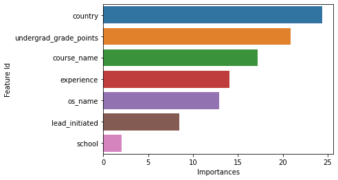

```python
# Features' importance

feat_imp = cat_model.get_feature_importance(prettified=True)
print(feat_imp)
# Plotting top 5 features' importance

# plt.figure(figsize = (12,8))
sns.barplot(feat_imp['Importances'],feat_imp['Feature Id'], orient = 'h')
plt.show()
```

```python
train_data = catboost.Pool(X_train, cat_features=cat_features)

interaction = cat_model.get_feature_importance(train_data, type="Interaction")
column_names = X_train.columns.values
interaction = pd.DataFrame(interaction, columns=["feature1", "feature2", "importance"])
interaction.feature1 = interaction.feature1.apply(lambda l: column_names[int(l)])
interaction.feature2 = interaction.feature2.apply(lambda l: column_names[int(l)])
interaction.head(20)
```

|  | feature1 | feature2 | importance |
| --- | --- | --- | --- |
| 0 | course_name | experience | 14.757841 |
| 1 | course_name | country | 13.069780 |
| 2 | course_name | os_name | 13.038056 |
| 3 | course_name | undergrad_grade_points | 8.237055 |
| 4 | country | experience | 6.911917 |
| 5 | country | os_name | 5.946899 |
| 6 | country | undergrad_grade_points | 5.396930 |
| 7 | os_name | undergrad_grade_points | 4.121983 |
| 8 | os_name | experience | 3.759463 |
| 9 | experience | undergrad_grade_points | 3.485279 |

```python
cat_model.get_all_params()
```

```
{'nan_mode': 'Min',
 'eval_metric': 'AUC',
 'combinations_ctr': ['Borders:CtrBorderCount=15:CtrBorderType=Uniform:TargetBorderCount=1:TargetBorderType=MinEntropy:Prior=0/1:Prior=0.5/1:Prior=1/1',
  'Counter:CtrBorderCount=15:CtrBorderType=Uniform:Prior=0/1'],
 'iterations': 5000,
 'sampling_frequency': 'PerTree',
 'fold_permutation_block': 0,
 'leaf_estimation_method': 'Newton',
 'od_pval': 0,
 'counter_calc_method': 'SkipTest',
 'grow_policy': 'SymmetricTree',
 'penalties_coefficient': 1,
 'boosting_type': 'Plain',
 'model_shrink_mode': 'Constant',
 'feature_border_type': 'GreedyLogSum',
 'ctr_leaf_count_limit': 18446744073709551615,
 'bayesian_matrix_reg': 0.10000000149011612,
 'one_hot_max_size': 2,
 'l2_leaf_reg': 3,
 'random_strength': 1,
 'od_type': 'Iter',
 'rsm': 1,
 'boost_from_average': False,
 'max_ctr_complexity': 4,
 'model_size_reg': 0.5,
 'simple_ctr': ['Borders:CtrBorderCount=15:CtrBorderType=Uniform:TargetBorderCount=1:TargetBorderType=MinEntropy:Prior=0/1:Prior=0.5/1:Prior=1/1',
  'Counter:CtrBorderCount=15:CtrBorderType=Uniform:Prior=0/1'],
 'pool_metainfo_options': {'tags': {}},
 'subsample': 0.800000011920929,
 'use_best_model': True,
 'od_wait': 200,
 'class_names': [0, 1],
 'random_seed': 42,
 'depth': 6,
 'ctr_target_border_count': 1,
 'posterior_sampling': False,
 'has_time': False,
 'store_all_simple_ctr': False,
 'border_count': 254,
 'classes_count': 0,
 'auto_class_weights': 'None',
 'sparse_features_conflict_fraction': 0,
 'leaf_estimation_backtracking': 'AnyImprovement',
 'best_model_min_trees': 1,
 'model_shrink_rate': 0,
 'min_data_in_leaf': 1,
 'loss_function': 'Logloss',
 'learning_rate': 0.03865500167012215,
 'score_function': 'Cosine',
 'task_type': 'CPU',
 'leaf_estimation_iterations': 10,
 'bootstrap_type': 'MVS',
 'max_leaves': 64,
 'permutation_count': 4}
```

```python
# # Preforming a Random Grid Search to find the best combination of parameters

# grid = {'iterations': [5000],
#         'learning_rate': [0.1, 0.2, 0.05],
#         'depth': [4, 6, 10, 16],
# #         'l2_leaf_reg': [1, 3, 5, 9]
#        }

# final_model = catboost.CatBoostClassifier(cat_features=cat_features,
#                                           verbose=False
#                                          )
# randomized_search_result = final_model.randomized_search(grid,
#                                                    X=X_train,
#                                                    y=y_train,
#                                                    verbose=False,
#                                                    plot=True)
```

```python
# Final Cat-Boost Regressor

params = {'iterations': 10000,
          'learning_rate': 0.05,
          'depth': 10,
#           'l2_leaf_reg': 1,
          'eval_metric':'F1',
          'early_stopping_rounds': 200,
          'verbose': 200,
          'random_seed': 42,
          'cat_features': cat_features
         }

cat_f = catboost.CatBoostClassifier(**params)
cat_model_f = cat_f.fit(X_train, y_train,
                     eval_set=(X_val, y_val),
                     plot=True,
                     verbose=False,
                     use_best_model=True)

catf_pred = cat_model_f.predict(X_test)
```

```python
cat_df = pd.concat([cat_df.reset_index(drop=True), pd.Series(catf_pred, name='y_pred_cat_f1')], axis=1)
cat_df
```

|  | profile_id | school | course_name | country | os_name | experience | lead_initiated | undergrad_grade_points | is_test | has_applied | has_enrolled | y_pred_cat_auc | y_pred_cat_f1 |
| --- | --- | --- | --- | --- | --- | --- | --- | --- | --- | --- | --- | --- | --- |
| 0 | 875719666990 | School A | Design | Kyrat |  | 5-10 Years | false | 88 | true | 0 | 0 | 0 | 0 |
| 1 | 797757524997 | School A | Design | Wakanda |  | 5-10 Years | false | 78 | true | 0 | 0 | 1 | 1 |
| 2 | 894083850249 | School B | Strategy | Alfheim | ios | 5-10 Years | false | 93 | true | 0 | 0 | 0 | 0 |
| 3 | 784948401197 | School B | Strategy | Gondour |  | 5-10 Years | false | 85 | true | 0 | 0 | 1 | 1 |
| 4 | 872404405944 | School B | Analytics | Gondour |  | 5-10 Years | false | 100 | true | 0 | 0 | 0 | 0 |
| ... | ... | ... | ... | ... | ... | ... | ... | ... | ... | ... | ... | ... | ... |
| 6510 | 795258323666 | School B | Strategy | Kyrat | windows | Less than 5 Years | true | 74 | true | 0 | 0 | 1 | 1 |
| 6511 | 882233245459 | School B | Strategy | Kyrat | mac os x | Less than 5 Years | true | 80 | true | 0 | 0 | 1 | 1 |
| 6512 | 793084004263 | School B | Strategy | Wakanda |  | Less than 5 Years | true | 82 | true | 0 | 0 | 1 | 1 |
| 6513 | 894771230271 | School B | Data Science | Arcadia | windows | Less than 5 Years | true | 93 | true | 0 | 0 | 0 | 0 |
| 6514 | 906232090619 | School B | Data Science | Spensonia |  | Less than 5 Years | true | 77 | true | 0 | 0 | 0 | 0 |

6515 rows × 13 columns

```python
catf_metrics = evaluate_model(y_test, catf_pred, 'catboost_grid')
print(catf_metrics['classification_report'])

catf_model_path = f"{MODEL_DIR}/catboost_grid_f1.pkl"
save_pickle_model(cat_model_f, catf_model_path)

catf_metrics
```

```
Evaluating catboost_grid...

              precision    recall  f1-score   support

           0       0.96      0.73      0.83      6200
           1       0.07      0.43      0.13       315

    accuracy                           0.72      6515
   macro avg       0.52      0.58      0.48      6515
weighted avg       0.92      0.72      0.80      6515
```

```
{'classification_report': '              precision    recall  f1-score   support\n\n           0       0.96      0.73      0.83      6200\n           1       0.07      0.43      0.13       315\n\n    accuracy                           0.72      6515\n   macro avg       0.52      0.58      0.48      …
 'confusion_matrix': [[4532, 1668], [181, 134]],
 'accuracy': 0.7161933998465081,
 'recall': 0.4253968253968254,
 'precision': 0.07436182019977802,
 'f1': 0.12659423712801132,
 'fpr': array([0.        , 0.26903226, 1.        ]),
 'tpr': array([0.        , 0.42539683, 1.        ]),
 'thresholds': array([2, 1, 0]),
 'tnr': 0.7309677419354839,
 'roc_auc_score': 0.5781822836661547}
```

```
               Feature Id  Importances
0  undergrad_grade_points    21.935281
1                 country    20.534375
2             course_name    16.894129
3              experience    16.891241
4                 os_name    12.844096
5          lead_initiated     9.037673
6                  school     1.863205
```

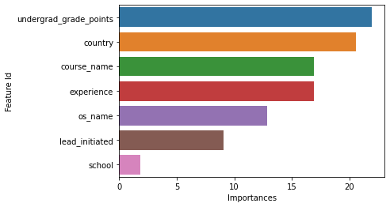

```python
# Features' importance

feat_imp = cat_model_f.get_feature_importance(prettified=True)
print(feat_imp)
# Plotting top 5 features' importance

# plt.figure(figsize = (12,8))
sns.barplot(feat_imp['Importances'],feat_imp['Feature Id'], orient = 'h')
plt.show()
```

```python
# Final Cat-Boost Regressor

params = {'iterations': 10000,
          'learning_rate': 0.05,
          'depth': 10,
#           'l2_leaf_reg': 1,
          'eval_metric': 'Precision',
          'early_stopping_rounds': 200,
          'verbose': 200,
          'random_seed': 42,
          'cat_features': cat_features
         }

cat_r = catboost.CatBoostClassifier(**params)
cat_model_r = cat_r.fit(X_train, y_train,
                     eval_set=(X_val, y_val),
                     plot=True,
                     verbose=False,
                     use_best_model=True)

catr_pred = cat_model_r.predict(X_test)
```

```python
cat_df = pd.concat([cat_df.reset_index(drop=True), pd.Series(catr_pred, name='y_pred_cat_precision')], axis=1)

cat_df.to_csv(f"{DATA_DIR}/test_annotation_catboost.csv", index=False)
cat_df
```

|  | profile_id | school | course_name | country | os_name | experience | lead_initiated | undergrad_grade_points | is_test | has_applied | has_enrolled | y_pred_cat_auc | y_pred_cat_f1 | y_pred_cat_precision |
| --- | --- | --- | --- | --- | --- | --- | --- | --- | --- | --- | --- | --- | --- | --- |
| 0 | 875719666990 | School A | Design | Kyrat |  | 5-10 Years | false | 88 | true | 0 | 0 | 0 | 0 | 0 |
| 1 | 797757524997 | School A | Design | Wakanda |  | 5-10 Years | false | 78 | true | 0 | 0 | 1 | 1 | 1 |
| 2 | 894083850249 | School B | Strategy | Alfheim | ios | 5-10 Years | false | 93 | true | 0 | 0 | 0 | 0 | 0 |
| 3 | 784948401197 | School B | Strategy | Gondour |  | 5-10 Years | false | 85 | true | 0 | 0 | 1 | 1 | 1 |
| 4 | 872404405944 | School B | Analytics | Gondour |  | 5-10 Years | false | 100 | true | 0 | 0 | 0 | 0 | 0 |
| ... | ... | ... | ... | ... | ... | ... | ... | ... | ... | ... | ... | ... | ... | ... |
| 6510 | 795258323666 | School B | Strategy | Kyrat | windows | Less than 5 Years | true | 74 | true | 0 | 0 | 1 | 1 | 1 |
| 6511 | 882233245459 | School B | Strategy | Kyrat | mac os x | Less than 5 Years | true | 80 | true | 0 | 0 | 1 | 1 | 1 |
| 6512 | 793084004263 | School B | Strategy | Wakanda |  | Less than 5 Years | true | 82 | true | 0 | 0 | 1 | 1 | 1 |
| 6513 | 894771230271 | School B | Data Science | Arcadia | windows | Less than 5 Years | true | 93 | true | 0 | 0 | 0 | 0 | 0 |
| 6514 | 906232090619 | School B | Data Science | Spensonia |  | Less than 5 Years | true | 77 | true | 0 | 0 | 0 | 0 | 0 |

6515 rows × 14 columns

```python
catr_metrics = evaluate_model(y_test, catr_pred, 'catboost_grid')
print(catr_metrics['classification_report'])

catr_model_path = f"{MODEL_DIR}/catboost_grid_precision.pkl"
save_pickle_model(cat_model_r, catr_model_path)

catr_metrics
```

```
Evaluating catboost_grid...

              precision    recall  f1-score   support

           0       0.96      0.74      0.84      6200
           1       0.07      0.39      0.12       315

    accuracy                           0.73      6515
   macro avg       0.52      0.57      0.48      6515
weighted avg       0.92      0.73      0.80      6515
```

```
{'classification_report': '              precision    recall  f1-score   support\n\n           0       0.96      0.74      0.84      6200\n           1       0.07      0.39      0.12       315\n\n    accuracy                           0.73      6515\n   macro avg       0.52      0.57      0.48      …
 'confusion_matrix': [[4615, 1585], [191, 124]],
 'accuracy': 0.7273983115886415,
 'recall': 0.39365079365079364,
 'precision': 0.07255705090696314,
 'f1': 0.12252964426877472,
 'fpr': array([0.        , 0.25564516, 1.        ]),
 'tpr': array([0.        , 0.39365079, 1.        ]),
 'thresholds': array([2, 1, 0]),
 'tnr': 0.7443548387096774,
 'roc_auc_score': 0.5690028161802355}
```

```
               Feature Id  Importances
0  undergrad_grade_points    23.143199
1                 country    20.066059
2              experience    16.889013
3             course_name    16.628504
4                 os_name    12.788144
5          lead_initiated     8.697041
6                  school     1.788040
```

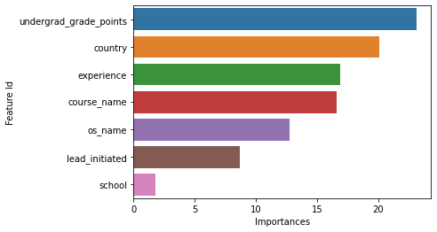

```python
# Features' importance

feat_imp = cat_model_r.get_feature_importance(prettified=True)
print(feat_imp)
# Plotting top 5 features' importance

# plt.figure(figsize = (12,8))
sns.barplot(feat_imp['Importances'],feat_imp['Feature Id'], orient = 'h')
plt.show()
```

#### XGBoost

```python
X_cat = df.select_dtypes(include=['object'])
X_enc = X_cat.copy()

X_enc = pd.get_dummies(X_enc, columns=cat_features)
X_enc
```

|  | profile_id | is_test | school_School A | school_School B | course_name_Analytics | course_name_B2B | course_name_Blockchain | course_name_Communication | course_name_Construction | course_name_Data Science | ... | experience_15-20 Years | experience_2 | experience_5 - 10 Years | experience_5-10 Years | experience_< 10 Years | experience_< 5 years | experience_> 20 Years | experience_Less than 5 Years | lead_initiated_false | lead_initiated_true |
| --- | --- | --- | --- | --- | --- | --- | --- | --- | --- | --- | --- | --- | --- | --- | --- | --- | --- | --- | --- | --- | --- |
| 0 | 757350438217 | false | 0 | 1 | 0 | 0 | 0 | 0 | 0 | 0 | ... | 0 | 0 | 0 | 0 | 0 | 1 | 0 | 0 | 1 | 0 |
| 1 | 173847491575 | false | 0 | 1 | 0 | 0 | 0 | 0 | 0 | 0 | ... | 0 | 0 | 0 | 1 | 0 | 0 | 0 | 0 | 1 | 0 |
| 2 | 875719666990 | true | 1 | 0 | 0 | 0 | 0 | 0 | 0 | 0 | ... | 0 | 0 | 0 | 1 | 0 | 0 | 0 | 0 | 1 | 0 |
| 3 | 437402894223 | false | 1 | 0 | 0 | 0 | 0 | 0 | 0 | 0 | ... | 0 | 0 | 0 | 1 | 0 | 0 | 0 | 0 | 1 | 0 |
| 4 | 186283660042 | false | 0 | 1 | 0 | 0 | 0 | 0 | 0 | 0 | ... | 0 | 0 | 0 | 1 | 0 | 0 | 0 | 0 | 1 | 0 |
| ... | ... | ... | ... | ... | ... | ... | ... | ... | ... | ... | ... | ... | ... | ... | ... | ... | ... | ... | ... | ... | ... |
| 36336 | 420179855306 | false | 0 | 1 | 0 | 0 | 0 | 0 | 0 | 0 | ... | 0 | 0 | 0 | 0 | 0 | 0 | 0 | 1 | 0 | 1 |
| 36337 | 723125277386 | false | 0 | 1 | 0 | 0 | 0 | 0 | 0 | 0 | ... | 0 | 0 | 0 | 0 | 0 | 0 | 0 | 1 | 0 | 1 |
| 36338 | 341269577723 | false | 0 | 1 | 0 | 0 | 0 | 0 | 0 | 0 | ... | 0 | 0 | 0 | 0 | 0 | 0 | 0 | 1 | 0 | 1 |
| 36339 | 736223075829 | false | 0 | 1 | 0 | 0 | 0 | 0 | 0 | 0 | ... | 0 | 0 | 0 | 0 | 0 | 0 | 0 | 1 | 0 | 1 |
| 36340 | 209331921389 | false | 0 | 1 | 0 | 0 | 0 | 0 | 0 | 0 | ... | 0 | 0 | 0 | 0 | 0 | 0 | 0 | 1 | 0 | 1 |

36341 rows × 52 columns

```python
data = pd.concat([df.drop(cat_features + ['is_test', 'profile_id'], axis=1), X_enc], axis=1)
train = data.loc[(data['is_test'] == 'false')]
test = data.loc[(data['is_test'] == 'true')]
train.shape, test.shape
```

```
((29826, 55), (6515, 55))
```

```python
X = train.drop(['profile_id', 'is_test', 'has_enrolled', 'has_applied'], axis=1)
y = train['has_applied']

# Oversampling the data
smote = SMOTE(random_state = 42)
X_oversampled, y_oversampled = smote.fit_resample(X, y)

X_train, X_val, y_train, y_val = train_test_split(X_oversampled, y_oversampled, test_size=0.3, random_state=42)
X_test, y_test = test.drop(['has_enrolled', 'has_applied'], axis=1), test['has_applied']

# X_train = X_train.drop(['profile_id', 'is_test'], axis=1)
# X_val = X_val.drop(['profile_id', 'is_test'], axis=1)
X_test = X_test.drop(['profile_id', 'is_test'], axis=1)

# XGB does not entertain '<' ',' '>' in column names
X_train.columns = X_train.columns.astype(str).str.replace('<', 'lt').str.replace('>', 'gt').str.replace(',', '')
X_val.columns = X_val.columns.astype(str).str.replace('<', 'lt').str.replace('>', 'gt').str.replace(',', '')
X_test.columns = X_test.columns.astype(str).str.replace('<', 'lt').str.replace('>', 'gt').str.replace(',', '')

print(X_train.shape, y_train.shape, X_val.shape, y_val.shape, X_test.shape, y_test.shape)
```

```
(38050, 51) (38050,) (16308, 51) (16308,) (6515, 51) (6515,)
```

```python
xgb_clf = xgb.XGBClassifier(random_state=42, learning_rate=0.2)
xgb_clf.fit(X_train, y_train,
           eval_set=[(X_val, y_val)],
            eval_metric='logloss',
            verbose=False)
```

```
XGBClassifier(base_score=0.5, booster='gbtree', colsample_bylevel=1,
              colsample_bynode=1, colsample_bytree=1, gamma=0, gpu_id=-1,
              importance_type='gain', interaction_constraints='',
              learning_rate=0.2, max_delta_step=0, max_depth=6,
              min_child_weight=1, missing=nan, monotone_constraints='()',
              n_estimators=100, n_jobs=8, num_parallel_tree=1, random_state=42,
              reg_alpha=0, reg_lambda=1, scale_pos_weight=1, subsample=1,
              tree_method='exact', validate_parameters=1, verbosity=None)
```

```python
y_pred_xgb = xgb_clf.predict(X_test)

xgb_metrics = evaluate_model(y_test, y_pred_xgb, 'XGBClassifier')
print(xgb_metrics['classification_report'])

xgb_model_path = f"{MODEL_DIR}/xgboost_baseline.pkl"
save_pickle_model(xgb_clf, xgb_model_path)

xgb_metrics
```

```
Evaluating XGBClassifier...

              precision    recall  f1-score   support

           0       0.92      0.93      0.92      5955
           1       0.17      0.16      0.16       560

    accuracy                           0.86      6515
   macro avg       0.54      0.54      0.54      6515
weighted avg       0.86      0.86      0.86      6515
```

```
{'classification_report': '              precision    recall  f1-score   support\n\n           0       0.92      0.93      0.92      5955\n           1       0.17      0.16      0.16       560\n\n    accuracy                           0.86      6515\n   macro avg       0.54      0.54      0.54      …
 'confusion_matrix': [[5515, 440], [471, 89]],
 'accuracy': 0.8601688411358404,
 'recall': 0.15892857142857142,
 'precision': 0.16824196597353497,
 'f1': 0.16345270890725436,
 'fpr': array([0.        , 0.07388749, 1.        ]),
 'tpr': array([0.        , 0.15892857, 1.        ]),
 'thresholds': array([2, 1, 0]),
 'tnr': 0.926112510495382,
 'roc_auc_score': 0.5425205409619768}
```

```python
xgb_df = pd.concat([test.reset_index(drop=True), pd.Series(y_pred_xgb, name='y_pred_xgb')], axis=1)
xgb_df.loc[(xgb_df['has_enrolled'] != xgb_df['y_pred_xgb'])]

xgb_df.to_csv(f"{DATA_DIR}/test_annotation_xgboost.csv", index=False)
```

```
[0.00233103 0.00540859 0.01413106 0.02321737 0.0145663  0.01733205
 0.01733558 0.01749212 0.02987841 0.02720954 0.01765092 0.02331388
 0.02238667 0.02229839 0.01675891 0.01333409 0.01770464 0.04505921
 0.0435257  0.03292315 0.01659943 0.02628018 0.01789594 0.03614298
 0.00865664 0.16771127 0.00622936 0.03104999 0.01345    0.0084586
 0.01852984 0.         0.         0.01373728 0.         0.03220821
 0.         0.02682328 0.         0.02177237 0.         0.01026404
 0.         0.         0.01026704 0.01184382 0.02398351 0.01397456
 0.02750197 0.01738997 0.01537214]
```

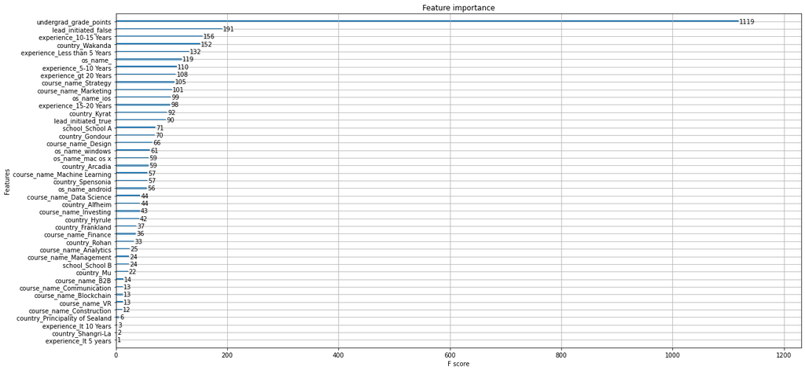

```python
# XGBoost Feature Importance
feat_imp = xgb_clf.feature_importances_
print(feat_imp)
# Plotting top 5 features' importance

fig, ax = plt.subplots(figsize=(20, 10))
xgb.plot_importance(xgb_clf, ax=ax)
plt.show()
```

### Model Evaluation

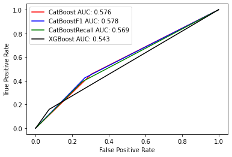

```python
# Get ROC-AUC curve
fpr_cat = cat_metrics.get("fpr")
tpr_cat = cat_metrics.get("tpr")
thresholds_cat = cat_metrics.get("thresholds")
auc_cat = cat_metrics.get("roc_auc_score")

fpr_catf = catf_metrics.get("fpr")
tpr_catf = catf_metrics.get("tpr")
thresholds_catf = catf_metrics.get("thresholds")
auc_catf = catf_metrics.get("roc_auc_score")

fpr_catr = catr_metrics.get("fpr")
tpr_catr = catr_metrics.get("tpr")
thresholds_catr = catr_metrics.get("thresholds")
auc_catr = catr_metrics.get("roc_auc_score")

fpr_xgb = xgb_metrics.get("fpr")
tpr_xgb = xgb_metrics.get("tpr")
thresholds_xgb = xgb_metrics.get("thresholds")
auc_xgb = xgb_metrics.get("roc_auc_score")


plt.plot(fpr_cat, tpr_cat,'r-',label = 'CatBoost AUC: %.3f'%auc_cat)
plt.plot(fpr_catf, tpr_catf,'b-', label= 'CatBoostF1 AUC: %.3f'%auc_catf)
plt.plot(fpr_catr, tpr_catr,'g-', label= 'CatBoostRecall AUC: %.3f'%auc_catr)
plt.plot(fpr_xgb, tpr_xgb,'k-',label='XGBoost AUC: %.3f'%auc_xgb)
plt.legend()
plt.xlabel('False Positive Rate')
plt.ylabel('True Positive Rate')
plt.show()
```

```python
# Compare all the metrics based on test dataset
pd.DataFrame(({"xgb_metrics":xgb_metrics, "cat_metrics_auc":cat_metrics, "cat_metrics_f1":catf_metrics, "cat_metrics_precision":catr_metrics}))
```

|  | xgb_metrics | cat_metrics_auc | cat_metrics_f1 | cat_metrics_precision |
| --- | --- | --- | --- | --- |
| classification_report | precision recall f1-score ... | precision recall f1-score ... | precision recall f1-score ... | precision recall f1-score ... |
| confusion_matrix | [[5515, 440], [471, 89]] | [[4308, 1892], [171, 144]] | [[4532, 1668], [181, 134]] | [[4615, 1585], [191, 124]] |
| accuracy | 0.860169 | 0.683346 | 0.716193 | 0.727398 |
| recall | 0.158929 | 0.457143 | 0.425397 | 0.393651 |
| precision | 0.168242 | 0.0707269 | 0.0743618 | 0.0725571 |
| f1 | 0.163453 | 0.122501 | 0.126594 | 0.12253 |
| fpr | [0.0, 0.07388748950461797, 1.0] | [0.0, 0.30516129032258066, 1.0] | [0.0, 0.26903225806451614, 1.0] | [0.0, 0.25564516129032255, 1.0] |
| tpr | [0.0, 0.15892857142857142, 1.0] | [0.0, 0.45714285714285713, 1.0] | [0.0, 0.4253968253968254, 1.0] | [0.0, 0.39365079365079364, 1.0] |
| thresholds | [2, 1, 0] | [2, 1, 0] | [2, 1, 0] | [2, 1, 0] |
| tnr | 0.926113 | 0.694839 | 0.730968 | 0.744355 |
| roc_auc_score | 0.542521 | 0.575991 | 0.578182 | 0.569003 |